# Lipid Differential Abundance Analysis

Maize Genetics Analysis

2026-04-24

# Overview

**Purpose**: Identify differentially abundant lipids across leaf developmental stages and phosphorus treatments using total ion current (TIC) normalization.

**Approach**: 1. Filter lipids by missingness (<20% missing values) 2. Filter samples by total ion current (library size) 3. Normalize to molar ion fractions (TIC normalization) 4. Apply limma-voom for differential abundance analysis 5. Model spatial and technical covariates

**Experimental factors**: - **Leaf tissue position**: Continuous gradient (leaf 1-4) - **Phosphorus treatment**: High P (+P) vs Low P (-P) - **Genotype**: Control (CTRL) vs Inversion 4m (INV4M)

**Effect size thresholds**: - Leaf predictors: |logFC| > 0.5 - Categorical predictors: |logFC| > 1.5

# Libraries

```r
library(edgeR)
library(ggplot2)
library(limma)
library(dplyr)
library(tidyr)
library(forcats)
library(ggrepel)
library(ggpubr)
library(cowplot)
library(ggtext)
```

# Data Loading

## Define Exclusions

**Purpose**: Remove internal standards and odd-chain lipids from analysis.

```r
internal_standards <- c(
  "CUDA", "LPE_17_1", "Sphingosine_17_1", "PC_25_0", "DG_18_1",
  "PG_34_0", "DG_12_0", "TG_17_0", "LPC_17_0", "PE_34", "Cholesterol"
)

odd_carbon <- c("PG_17_0", "SM_35_1", "TG_57_6")
to_exclude <- c(internal_standards, odd_carbon)
```

## Load Raw MS Data

**Purpose**: Load MS-DIAL peak areas with internal standard integration.

```r
lipid_csv <- file.path(paths$data, "PSU_RawData_MSDial_NewStdInt_240422.csv")

raw <- read.csv(lipid_csv, na.strings = c("", "#N/A", "NA", "Inf")) %>%
  select(-all_of(to_exclude[to_exclude %in% colnames(.)])) %>%
  filter(!grepl("Methanol|Pool", sampleID))

cat("Loaded samples:", nrow(raw), "\n")
```

```
## Loaded samples: 43
```

## Load Sample Metadata

**Purpose**: Merge phenotypic data with RNA-seq metadata and MS injection order.

```r
plant_csv <- file.path(paths$data, "22_NCS_PSU_LANGEBIO_FIELDS_PSU_P_field.csv")

psu <- read.csv(plant_csv) %>%
  dplyr::rename(Genotype = "Who.What", rowid = "P22.") %>%
  filter(Genotype %in% c("CTRL", "INV4M")) %>%
  droplevels()

sampleInfo <- read.csv(file.path(paths$data, "PSU2022_metadata.csv")) %>%
  dplyr::rename(rowid = row)

# New metadata already has Rep, Plot_Row, Plot_Column - only get DTA/DTS from psu
sampleInfo <- psu %>%
  select(rowid, DTA, DTS) %>%
  inner_join(sampleInfo, by = "rowid") %>%
  filter(!is.na(DTA))

sampleInfo$leaf_group <- NA
sampleInfo$leaf_group[sampleInfo$leaf_tissue < 3] <- "apical"
sampleInfo$leaf_group[sampleInfo$leaf_tissue > 2] <- "basal"

sampleInfo$tube <- gsub("L|R", "S", sampleInfo$top_tag, perl = TRUE)

ms_order <- read.csv(file.path(paths$data, "PSU-PHO22_ms_order.csv"))
ms_order$tube <- gsub("L|R", "S", ms_order$top_tag, perl = TRUE)

# Only get injection_order from ms_order to avoid duplicate columns
sampleInfo <- sampleInfo %>%
  dplyr::inner_join(ms_order %>% select(tube, injection_order), by = "tube") %>%
  distinct()

cat("Sample info loaded:", nrow(sampleInfo), "samples\n")
```

```
## Sample info loaded: 44 samples
```

## Merge Lipid Data with Metadata

**Purpose**: Combine MS peak areas with sample metadata.

```r
raw$tube <- gsub(".*_|.raw", "", raw$sampleID, perl = TRUE)
raw$tube <- gsub("L|R", "S", raw$tube, perl = TRUE)

pheno <- sampleInfo %>%
  select(rowid, tube, Rep, Plot:Plot_Row, Treatment:leaf_tissue,
         leaf_group, injection_order) %>%
  inner_join(raw %>% select(tube, DGDG_34_0:TG_58_5)) %>%
  mutate(
    block = as.factor(Rep),
    Treatment = factor(Treatment, levels = c("High_P", "Low_P"))
  ) %>%
  pivot_wider(
    names_from = Rep,
    values_from = Rep,
    names_prefix = "block_",
    values_fn = function(x) 1,
    values_fill = 0
  ) %>%
  select(rowid, tube:Plot_Row, block, block_6:block_12,
         injection_order, everything())

levels(pheno$Treatment) <- c("+P", "-P")

cat("Final dataset:", nrow(pheno), "samples\n")
```

```
## Final dataset: 43 samples
```

## Define Lipid Classifications

**Purpose**: Annotate lipids by head group and class for downstream analysis.

```r
m <- pheno %>%
  select(DGDG_34_0:TG_58_5) %>%
  as.matrix()

head_group <- c(
  DG = "neutral", DGDG = "glycolipid", DGGA = "glycolipid",
  LPC = "phospholipid", LPE = "phospholipid", MGDG = "glycolipid",
  PC = "phospholipid", PE = "phospholipid", PG = "phospholipid",
  PI = "phospholipid", SQDG = "glycolipid", TG = "neutral"
)

sp <- data.frame(
  colname = colnames(m),
  class = gsub("_.*", "", colnames(m), perl = TRUE)
)
sp$head_group <- head_group[sp$class]

cat("\nLipid class distribution:\n")
```

```
##
## Lipid class distribution:
```

```r
print(with(sp, table(head_group, class)))
```

```
##               class
## head_group     DG DGDG DGGA LPC LPE MGDG PC PE PG PI SQDG TG
##   glycolipid    0   12    9   0   0    8  0  0  0  0    9  0
##   neutral      22    0    0   0   0    0  0  0  0  0    0 25
##   phospholipid  0    0    0   6   3    0 19 12  6  4    0  0
```

# Quality Control

## Create Count Matrix

**Purpose**: Prepare lipid abundance matrix for filtering and normalization.

```r
counts <- t(m)
colnames(counts) <- pheno$tube

cat("Count matrix dimensions:", dim(counts), "\n")
```

```
## Count matrix dimensions: 135 43
```

```r
cat("Lipids:", nrow(counts), "\n")
```

```
## Lipids: 135
```

```r
cat("Samples:", ncol(counts), "\n")
```

```
## Samples: 43
```

## Raw Data Distribution

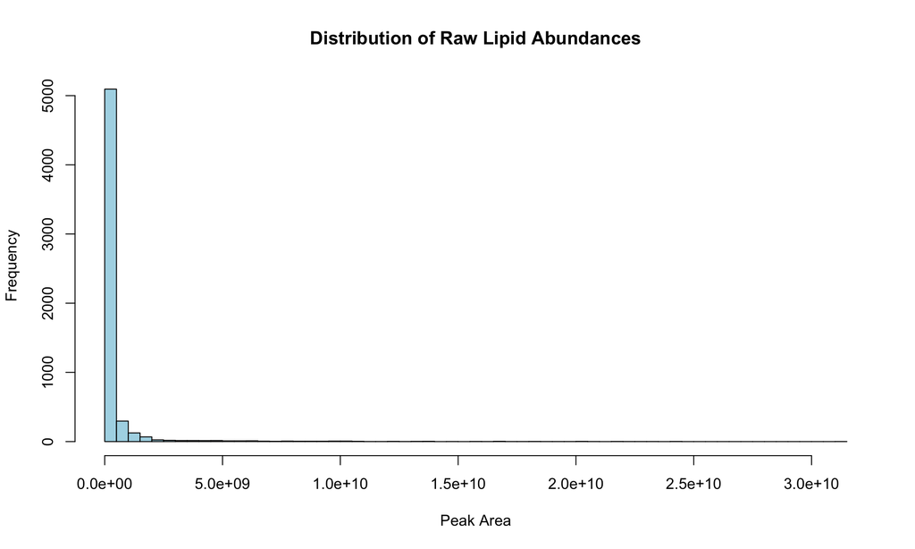

```r
hist(counts,
     main = "Distribution of Raw Lipid Abundances",
     xlab = "Peak Area",
     breaks = 50,
     col = "lightblue")
```

## Missing Data Analysis

**Purpose**: Identify lipids with excessive missing values for removal.

**Approach**: Calculate proportion of missing/zero values per lipid and set threshold at 20%.

```r
missing_per_lipid <- rowSums(is.na(counts) | counts == 0) / ncol(counts)

cat("Missing data summary:\n")
```

```
## Missing data summary:
```

```r
print(summary(missing_per_lipid))
```

```
##    Min. 1st Qu.  Median    Mean 3rd Qu.    Max.
## 0.00000 0.00000 0.00000 0.01585 0.00000 0.27907
```

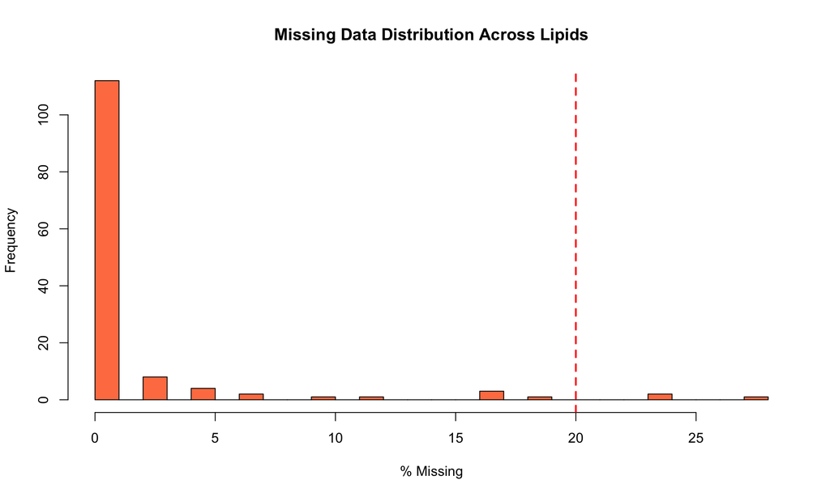

```r
hist(missing_per_lipid * 100,
     main = "Missing Data Distribution Across Lipids",
     xlab = "% Missing",
     breaks = 30,
     col = "coral")
abline(v = 20, col = "red", lwd = 2, lty = 2)
```

## Filter Lipids by Missingness

**Purpose**: Remove lipids with >20% missing values across samples.

```r
missing_threshold <- 0.20
keep_lipids <- missing_per_lipid < missing_threshold

cat("Lipid filtering (< 20% missing):\n")
```

```
## Lipid filtering (< 20% missing):
```

```r
cat("  Before:", nrow(counts), "\n")
```

```
##   Before: 135
```

```r
cat("  After:", sum(keep_lipids), "\n")
```

```
##   After: 132
```

```r
cat("  Removed:", sum(!keep_lipids), "\n")
```

```
##   Removed: 3
```

```r
counts_filtered <- counts[keep_lipids, ]
```

## Match Sample Metadata

**Purpose**: Ensure sample metadata matches filtered count matrix.

```r
sampleNames <- colnames(counts_filtered)

sampleInfo_matched <- sampleInfo[match(sampleNames, sampleInfo$tube), ]

sampleInfo_matched$Treatment <- factor(
  pheno$Treatment[match(sampleInfo_matched$tube, pheno$tube)],
  levels = c("+P", "-P")
)

cat("Treatment levels:\n")
```

```
## Treatment levels:
```

```r
print(table(sampleInfo_matched$Treatment))
```

```
##
## +P -P
## 16 27
```

## Library Size Diagnostics

**Purpose**: Identify samples with insufficient total ion current for removal.

**Approach**: Calculate total peak area per sample (library size) and visualize distribution to determine filtering threshold.

```r
genes <- data.frame(gene = rownames(counts_filtered))

y_raw <- DGEList(counts = counts_filtered, samples = sampleInfo_matched)
y_raw$group <- interaction(y_raw$samples$Treatment, y_raw$samples$Genotype)

cat("Library size summary (before filtering):\n")
```

```
## Library size summary (before filtering):
```

```r
print(summary(y_raw$samples$lib.size))
```

```
##      Min.   1st Qu.    Median      Mean   3rd Qu.      Max.
## 6.026e+09 4.078e+10 5.495e+10 5.752e+10 7.071e+10 1.110e+11
```

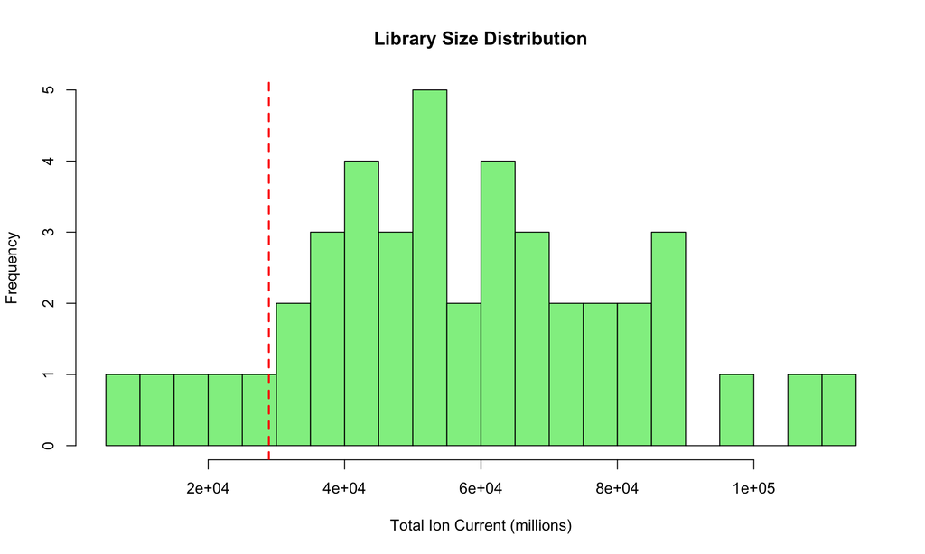

```r
hist(
  y_raw$samples$lib.size / 1e6,
  main = "Library Size Distribution",
  xlab = "Total Ion Current (millions)",
  breaks = 30,
  col = "lightgreen"
)

lib_size_threshold <- quantile(y_raw$samples$lib.size, 0.10)
abline(v = lib_size_threshold / 1e6, col = "red", lwd = 2, lty = 2)
```

```r
cat("Suggested threshold (10th percentile):", lib_size_threshold, "\n")
```

```
## Suggested threshold (10th percentile): 28898886284
```

## Filter Samples by Library Size

**Purpose**: Remove samples with low total ion current that may compromise data quality.

**Expected outcome**: Retain samples with sufficient signal for reliable quantification.

```r
# min_lib_size <- 3e10
min_lib_size <- 1

keep_samples <- y_raw$samples$lib.size >= min_lib_size

cat("Sample filtering (TIC >=", min_lib_size, "):\n")
```

```
## Sample filtering (TIC >= 1 ):
```

```r
cat("  Before:", ncol(counts_filtered), "\n")
```

```
##   Before: 43
```

```r
cat("  After:", sum(keep_samples), "\n")
```

```
##   After: 43
```

```r
cat("  Removed:", sum(!keep_samples), "\n")
```

```
##   Removed: 0
```

```r
if (sum(!keep_samples) > 0) {
  cat("\nRemoved samples:\n")
  print(y_raw$samples[!keep_samples,
                       c("tube", "lib.size", "Treatment",
                         "Genotype", "leaf_tissue")])
}

y <- y_raw[, keep_samples]
y$samples <- droplevels(y$samples)
```

## MDS: Library Size Quality Control

**Purpose**: Visualize sample relationships colored by library size to assess filtering quality.

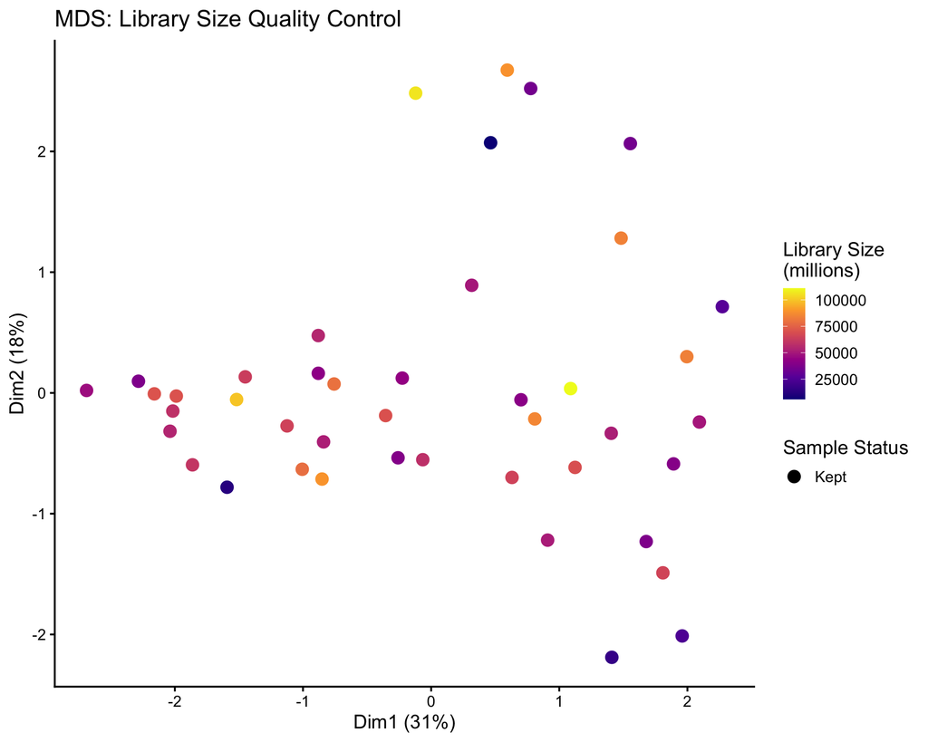

```r
mds_all <- plotMDS(y_raw, plot = FALSE)

mds_qc_data <- y_raw$samples %>%
  mutate(
    dim1 = mds_all$x,
    dim2 = mds_all$y,
    lib_size = lib.size / 1e6,
    filtered_out = !keep_samples
  )

ggplot(mds_qc_data,
       aes(x = dim1, y = dim2,
           color = lib_size,
           shape = filtered_out)) +
  geom_point(size = 4) +
  scale_color_viridis_c(option = "plasma") +
  scale_shape_manual(
    values = c("TRUE" = 4, "FALSE" = 19),
    labels = c("Kept", "Removed")
  ) +
  labs(
    x = paste0("Dim1 (", round(100 * mds_all$var.explained[1]), "%)"),
    y = paste0("Dim2 (", round(100 * mds_all$var.explained[2]), "%)"),
    color = "Library Size\n(millions)",
    shape = "Sample Status",
    title = "MDS: Library Size Quality Control"
  ) +
  theme_classic(base_size = 15)
```

## MDS: Injection Order Effect

**Purpose**: Assess technical drift associated with MS injection order.

```r
mds12_qc <- ggplot(mds_qc_data %>% filter(!filtered_out),
       aes(x = dim1, y = dim2,
           fill = injection_order,
           shape = Treatment)) +
  geom_point(size = 4, color ="transparent") +
  scale_fill_viridis_c(option = "plasma") +
  scale_shape_manual(values = c(21, 25)) +
  labs(
    x = paste0("dim1 (", round(100 * mds_all$var.explained[1]), "%)"),
    y = paste0("dim2 (", round(100 * mds_all$var.explained[2]), "%)"),
    # color = "Injection Order",
   # title = "MDS: Injection Order Effect"
  ) +
    guides(
    fill = guide_colourbar(
      title="Mass Spectrometry Injection Order",
      direction = "horizontal",
      barwidth = 15,
      barheight = 1,
      title.position = "top",
      title.hjust = 0.5),
    shape = guide_legend(
      title = "Treatment",
      override.aes = list(fill = "black"),
      reverse=TRUE)
    ) +
  coord_equal()+
  theme_classic(base_size = 15) +
  theme(legend.position = "top")
cor(mds_qc_data$dim1, mds_qc_data$injection_order, use="complete.obs")
```

```
## [1] 0.9632738
```

```r
cor.test(mds_qc_data$dim1, mds_qc_data$injection_order, use="complete.obs")
```

```
##
##  Pearson's product-moment correlation
##
## data:  mds_qc_data$dim1 and mds_qc_data$injection_order
## t = 22.97, df = 41, p-value < 2.2e-16
## alternative hypothesis: true correlation is not equal to 0
## 95 percent confidence interval:
##  0.9328021 0.9800702
## sample estimates:
##       cor
## 0.9632738
```

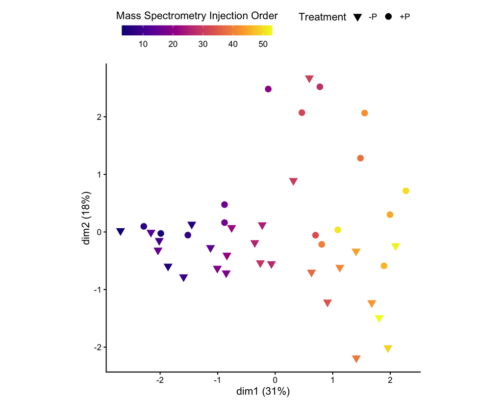

```r
print(mds12_qc)
```

# Total Ion Current Normalization

## Calculate Molar Ion Fractions

**Purpose**: Normalize lipid abundances to total ion current (TIC), converting raw peak areas to molar ion fractions.

**Approach**: For each sample, divide each lipid’s peak area by the total peak area. This accounts for differences in total signal between samples and expresses abundances as proportions.

**Expected outcome**: Molar ion fractions sum to 1.0 per sample, representing each lipid’s proportion of the total detected lipid pool.

```r
cat("=== Calculating Molar Ion Fractions ===\n")
```

```
## === Calculating Molar Ion Fractions ===
```

```r
raw_counts <- y$counts

molar_ion_fractions <- sweep(raw_counts, 2, colSums(raw_counts), FUN = "/")

cat("Molar ion fraction range:", range(molar_ion_fractions), "\n")
```

```
## Molar ion fraction range: 0 0.3637007
```

```r
cat("Sample sums (should be 1):",
    unique(round(colSums(molar_ion_fractions), 10)), "\n")
```

```
## Sample sums (should be 1): 1
```

## Scale for Voom

**Purpose**: Convert molar ion fractions to count-like scale for voom transformation.

**Approach**: Multiply fractions by 1e9 to create numerically stable values that voom can process while maintaining the TIC normalization.

```r
scaled_fractions <- molar_ion_fractions * 1e9

y_ion <- DGEList(counts = scaled_fractions, samples = y$samples)
y_ion$samples$norm.factors <- 1

cat("Scaled molar ion fractions created\n")
```

```
## Scaled molar ion fractions created
```

```r
cat("Library size summary (should be ~1e9):\n")
```

```
## Library size summary (should be ~1e9):
```

```r
print(summary(y_ion$samples$lib.size))
```

```
##    Min. 1st Qu.  Median    Mean 3rd Qu.    Max.
##   1e+09   1e+09   1e+09   1e+09   1e+09   1e+09
```

# Lipid Class Composition

```r
## Calculate class-level abundances from normalized data

# Extract normalized counts (ion fraction scaled)

# Create metadata for normalized samples
norm_metadata <- y$samples %>%
  dplyr::filter(tube %in% colnames(scaled_fractions))

# Transpose normalized counts and merge with lipid annotations
lipid_abundance <- scaled_fractions %>%
  t() %>%
  as.data.frame() %>%
  dplyr::mutate(tube = rownames(.)) %>%
  tidyr::pivot_longer(
    cols = -tube,
    names_to = "response",
    values_to = "abundance"
  ) %>%
  dplyr::inner_join(sp, by = c("response" = "colname")) %>%
  dplyr::inner_join(norm_metadata, by = "tube")

# Get classes by head group from sp annotation
classes_by_headgroup <- sp %>%
  dplyr::select(class, head_group) %>%
  dplyr::distinct() %>%
  dplyr::arrange(head_group, class)

# Order classes by head group for consistent display
class_order <- classes_by_headgroup %>%
  dplyr::pull(class)

# Define custom green to orange palette for leaf positions
green_to_orange <- c(
  "#00954A",  # Spanish Green (Leaf 1)
  "#A4DF56",  # Inchworm (Leaf 2)
  "#D7E23C",  # Pear (Leaf 3)
  "#FF9A1F"   # Crayola's Bright Yellow/Orange (Leaf 4)
)

## Plot 1: Mean composition by Leaf position - grouped bars by leaf within each class

leaf_composition <- lipid_abundance %>%
  dplyr::group_by(tube, Treatment, leaf_tissue, class) %>%
  dplyr::summarise(class_sum = sum(abundance), .groups = "drop") %>%
  dplyr::group_by(tube, Treatment, leaf_tissue) %>%
  dplyr::mutate(class_pct = 100 * class_sum / sum(class_sum)) %>%
  dplyr::ungroup() %>%
  dplyr::group_by(Treatment, leaf_tissue, class) %>%
  dplyr::summarise(
    mean_pct = mean(class_pct),
    se_pct = sd(class_pct) / sqrt(n()),
    .groups = "drop"
  )

leaf_composition$class <- factor(leaf_composition$class, levels = class_order)

# Create leaf position factor
leaf_composition <- leaf_composition %>%
  dplyr::mutate(
    leaf_position = factor(
      leaf_tissue,
      levels = c(1, 2, 3, 4),
      labels = c("1", "2", "3", "4")
    )
  )

# Add head group for faceting
leaf_composition <- leaf_composition %>%
  dplyr::inner_join(
    sp %>% dplyr::select(class, head_group) %>% dplyr::distinct(),
    by = "class"
  )

# Plot with lipid classes on x-axis, grouped by leaf position, log Y-scale
plot1_composition <- leaf_composition %>%
  ggplot(aes(x = class, y = mean_pct, fill = leaf_position)) +
  geom_col(color = "black", linewidth = 0.2, position = position_dodge(width = 0.9)) +
  geom_errorbar(
    aes(ymin = mean_pct - se_pct, ymax = mean_pct + se_pct),
    position = position_dodge(width = 0.9),
    width = 0.25,
    linewidth = 0.5
  ) +
  scale_fill_manual(
    name = "Leaf",
    values = green_to_orange
  ) +
  scale_y_log10(
    breaks = c(0.05, 0.1, 0.2, 0.5, 1, 2, 5, 10, 20, 40),
    labels = c("0.05", "0.1", "0.2", "0.5", "1", "2", "5", "10", "20", "40")
  ) +
  labs(
    y = "Ion %"
  ) +
  facet_grid(rows = vars(Treatment), cols = vars(head_group),
             scales = "free_x", space = "free_x") +
  theme_classic2(base_size = 14) +
  theme(
    axis.title.x = element_blank(),
    axis.text.x = element_text(angle = 0, hjust = 0.5, size = 13, face = "bold"),
    strip.background = element_blank(),
    strip.text.x = element_text(angle = 0, size = 25, face = "bold"),
    strip.text.y = element_text(angle = 0, size = 25, face = "bold"),
    legend.position = "none"
  )

## Plot 2: Treatment effect (-P vs +P) by leaf stage

# Calculate mean and SE per Treatment-Leaf-Class
class_abundance_summary <- lipid_abundance %>%
  dplyr::group_by(tube, Treatment, leaf_tissue, class) %>%
  dplyr::summarise(class_sum = sum(abundance), .groups = "drop") %>%
  dplyr::group_by(Treatment, leaf_tissue, class) %>%
  dplyr::summarise(
    mean_abundance = mean(class_sum),
    se_abundance = sd(class_sum) / sqrt(n()),
    n_samples = n(),
    .groups = "drop"
  )

# Pivot to get +P and -P side by side
treatment_comparison <- class_abundance_summary %>%
  tidyr::pivot_wider(
    names_from = Treatment,
    values_from = c(mean_abundance, se_abundance, n_samples)
  ) %>%
  dplyr::mutate(
    # Calculate log2 fold change: log2(-P / +P)
    log2fc = log2(`mean_abundance_-P` / `mean_abundance_+P`),

    # Propagate error using delta method
    # For log2(Y/X): SE ≈ 1/ln(2) × sqrt((SE_Y/Y)^2 + (SE_X/X)^2)
    se_log2fc = (1/log(2)) * sqrt(
      (`se_abundance_-P` / `mean_abundance_-P`)^2 +
      (`se_abundance_+P` / `mean_abundance_+P`)^2
    )
  ) %>%
  dplyr::mutate(
    leaf_position = factor(
      leaf_tissue,
      levels = c(1, 2, 3, 4),
      labels = c("1", "2", "3", "4")
    )
  )

treatment_comparison$class <- factor(
  treatment_comparison$class,
  levels = class_order
)

# Add head group
treatment_comparison <- treatment_comparison %>%
  dplyr::inner_join(
    sp %>% dplyr::select(class, head_group) %>% dplyr::distinct(),
    by = "class"
  )

# Plot treatment effect
plot2_treatment_effect <- treatment_comparison %>%
  ggplot(aes(x = class, y = log2fc, fill = leaf_position)) +
  geom_col(color = "black", linewidth = 0.2, position = position_dodge(width = 0.9)) +
  geom_errorbar(
    aes(ymin = log2fc - se_log2fc, ymax = log2fc + se_log2fc),
    position = position_dodge(width = 0.9),
    width = 0.25,
    linewidth = 0.5
  ) +
  scale_fill_manual(
    name = "Leaf",
    values = green_to_orange
  ) +
  labs(
    y = expression(log[2]~"FC (-P / +P)")
  ) +
  facet_grid(cols = vars(head_group), scales = "free_x", space = "free_x") +
  theme_classic2(base_size = 14) +
  theme(
    axis.title.x = element_blank(),
    axis.text.x = element_text(angle = 0, hjust = 0.5, size = 13, face = "bold"),
    strip.background = element_blank(),
    strip.text.x = element_blank(),
  )


## Plot 3: Relative change with paired fold changes per plant

# Get sample-level abundances with plant ID
class_abundance_samples <- lipid_abundance %>%
  dplyr::group_by(tube, NCSU_RNA_plant, Treatment, leaf_tissue, class) %>%
  dplyr::summarise(class_sum = sum(abundance), .groups = "drop")

# Pivot wide to get all leaves per plant
class_abundance_wide <- class_abundance_samples %>%
  dplyr::select(-tube) %>%
  tidyr::pivot_wider(
    names_from = leaf_tissue,
    values_from = class_sum,
    names_prefix = "leaf_"
  )

# Fill missing values with treatment-class mean for that leaf
class_abundance_filled <- class_abundance_wide %>%
  dplyr::group_by(Treatment, class) %>%
  dplyr::mutate(
    leaf_1 = ifelse(is.na(leaf_1), mean(leaf_1, na.rm = TRUE), leaf_1),
    leaf_2 = ifelse(is.na(leaf_2), mean(leaf_2, na.rm = TRUE), leaf_2),
    leaf_3 = ifelse(is.na(leaf_3), mean(leaf_3, na.rm = TRUE), leaf_3),
    leaf_4 = ifelse(is.na(leaf_4), mean(leaf_4, na.rm = TRUE), leaf_4)
  ) %>%
  dplyr::ungroup()

# Calculate log2 fold change per plant (keeping leaf 1 = 0 for symmetry)
class_relative_per_plant <- class_abundance_filled %>%
  dplyr::mutate(
    leaf1_log2fc = 0,
    leaf2_log2fc = log2(leaf_2 / leaf_1),
    leaf3_log2fc = log2(leaf_3 / leaf_1),
    leaf4_log2fc = log2(leaf_4 / leaf_1)
  ) %>%
  dplyr::select(NCSU_RNA_plant, Treatment, class,
                leaf1_log2fc, leaf2_log2fc, leaf3_log2fc, leaf4_log2fc) %>%
  tidyr::pivot_longer(
    cols = starts_with("leaf"),
    names_to = "leaf_position",
    values_to = "log2fc"
  )

# Calculate mean and SE
class_leaf_ratio_treatment <- class_relative_per_plant %>%
  dplyr::group_by(Treatment, leaf_position, class) %>%
  dplyr::summarise(
    mean_log2fc = mean(log2fc, na.rm = TRUE),
    se_log2fc = sd(log2fc, na.rm = TRUE) / sqrt(n()),
    .groups = "drop"
  ) %>%
  dplyr::mutate(
    leaf_position = factor(
      leaf_position,
      levels = c("leaf1_log2fc", "leaf2_log2fc", "leaf3_log2fc", "leaf4_log2fc"),
      labels = c("1", "2", "3", "4")
    )
  )

class_leaf_ratio_treatment$class <- factor(
  class_leaf_ratio_treatment$class,
  levels = class_order
)

# Add head group
class_leaf_ratio_treatment <- class_leaf_ratio_treatment %>%
  dplyr::inner_join(
    sp %>% dplyr::select(class, head_group) %>% dplyr::distinct(),
    by = "class"
  )

# Plot with log2FC
plot3_leaf_relative <- class_leaf_ratio_treatment %>%
  ggplot(aes(x = class, y = mean_log2fc, fill = leaf_position)) +
  geom_col(color = "black", linewidth = 0.2, position = position_dodge(width = 0.9)) +
  geom_errorbar(
    aes(ymin = mean_log2fc - se_log2fc, ymax = mean_log2fc + se_log2fc),
    position = position_dodge(width = 0.9),
    width = 0.25,
    linewidth = 0.5
  ) +
  scale_fill_manual(
    name = "Leaf",
    values = green_to_orange
  ) +
  labs(
    y = expression(log[2]~"FC vs Leaf 1")
  ) +
  facet_grid(rows = vars(Treatment), cols = vars(head_group),
             scales = "free_x", space = "free_x") +
  theme_classic2(base_size = 14) +
  theme(
    axis.title.x = element_blank(),
    axis.text.x = element_text(angle = 0, hjust = 0.5, size = 13, face = "bold"),
    strip.background = element_blank(),
    strip.text.x = element_blank(),
    strip.text.y = element_text(angle = 0, size = 25, face = "bold"),
    legend.position = "none"
  )


# Combine all three plots
final_combined <- plot_grid(
  plot1_composition,
  plot2_treatment_effect,
  plot3_leaf_relative,
  ncol = 1,
  labels = c("A", "B", "C"),
  label_size = 25,
  rel_heights = c(1, 0.5, 1),
  align = "v",
  axis = "lr"
)

# Save combined plot
ggsave(
  file.path(paths$figures, "lipid_composition_combined_final.svg"),
  final_combined,
  width = 10,
  height = 10,
  dpi = 150
)
cat("\nFinal combined plot created and saved\n")
```

```
##
## Final combined plot created and saved
```

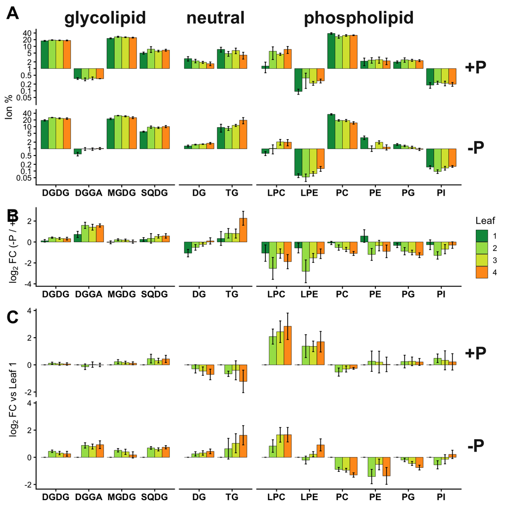

```r
print(final_combined)
```

# Multidimensional Scaling

## Compute MDS Dimensions

**Purpose**: Reduce dimensionality to visualize major sources of variation in lipid profiles.

**Approach**: Apply multidimensional scaling to TIC-normalized data, extracting first 4 dimensions.

```r
mds <- plotMDS(y_ion, plot = FALSE)

d <- y_ion$samples
d$dim1 <- mds$x
d$dim2 <- mds$y
d$dim3 <- mds$eigen.vectors[, 3] * sqrt(mds$var.explained[3])
d$dim4 <- mds$eigen.vectors[, 4] * sqrt(mds$var.explained[4])

d$Treatment <- factor(d$Treatment)
d$Genotype <- factor(d$Genotype)

cat("Variance explained by MDS dimensions:\n")
```

```
## Variance explained by MDS dimensions:
```

```r
print(tibble(
  dimension = paste("Dim", 1:4),
  var_explained = round(mds$var.explained[1:4], 4)
))
```

```
## # A tibble: 4 × 2
##   dimension var_explained
##   <chr>             <dbl>
## 1 Dim 1            0.337
## 2 Dim 2            0.170
## 3 Dim 3            0.116
## 4 Dim 4            0.0753
```

## MDS: Experimental Factors

**Purpose**: Identify which experimental and technical factors drive major axes of variation.

```r
p1 <- ggplot(d, aes(x = dim2, y = dim3, color = Treatment)) +
  geom_point(size = 3)  +
  xlab(paste0("dim2 (", round(100 * mds$var.explained[2]), "%)")) +
  ylab(paste0("dim3 (", round(100 * mds$var.explained[3]), "%)")) +
  theme_classic(base_size = 15)


p2 <- ggplot(d, aes(x = dim2, y = dim3,
                    color = injection_order)) +
  geom_point(size = 3) +
    scale_color_viridis_c(option = "plasma") +
  xlab(paste0("dim2 (", round(100 * mds$var.explained[2]), "%)")) +
  ylab(paste0("dim3 (", round(100 * mds$var.explained[3]), "%)")) +
  labs(color= "Injection\norder") +
  theme_classic(base_size = 15)

p3 <- ggplot(d, aes(x = dim2, y = dim3, color = decimal_time)) +
  geom_point(size = 3) +
  scale_color_viridis_c(option = "plasma") +
  labs(color= "Collection\ntime")  +
  xlab(paste0("dim2 (", round(100 * mds$var.explained[2]), "%)")) +
  ylab(paste0("dim3 (", round(100 * mds$var.explained[3]), "%)")) +
  theme_classic(base_size = 15)


p4 <- ggplot(d, aes(x = dim2, y = dim3, color = COLLECTOR)) +
  geom_point(size = 3) +
  scale_color_discrete(
    labels = c("Team 1", "Team 2")
  ) +
  theme_classic(base_size = 15)  +
  xlab(paste0("dim2 (", round(100 * mds$var.explained[2]), "%)")) +
  ylab(paste0("dim3 (", round(100 * mds$var.explained[3]), "%)")) +
  labs(color="Collector")

p5 <- ggplot(d, aes(x = dim2, y = dim3, color = Genotype)) +
  geom_point(size = 3) +
  theme_classic(base_size = 15)  +
  xlab(paste0("dim2 (", round(100 * mds$var.explained[2]), "%)")) +
  ylab(paste0("dim3 (", round(100 * mds$var.explained[3]), "%)")) +
  labs(color="Genotype")

p6 <- d %>%
  mutate(leaf = factor(leaf_tissue)) %>%
  ggplot(aes(x = dim2, y = dim3, color = leaf)) +
  scale_color_manual(values=green_to_orange)+
  geom_point(size = 3) +
  theme_classic(base_size = 15)  +
  xlab(paste0("dim2 (", round(100 * mds$var.explained[2]), "%)")) +
  ylab(paste0("dim3 (", round(100 * mds$var.explained[3]), "%)")) +
  labs(color = "Leaf")

mds_23_qc<- ggarrange(p1, p2, p3, p4, p5, p6, ncol = 2, nrow = 3)

sup_fig <- ggarrange(
  mds12_qc,
  mds_23_qc,
  nrow = 1,
  ncol=2,
  widths = c(0.7,1),
  labels="AUTO",
  font.label = list(size = 25))

# Save combined plot
ggsave(
  file.path(paths$figures, "sup_fig_7.png"),
  sup_fig,
  width = 16,
  height = 9,
  dpi = 150
)

cat("\nFinal combined plot created and saved\n")
```

```
##
## Final combined plot created and saved
```

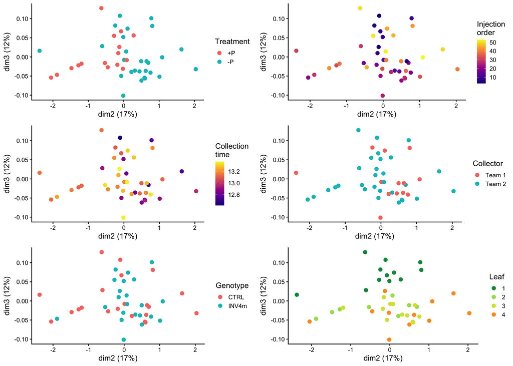

```r
print(mds_23_qc)
```

## MDS: Primary Plot

**Purpose**: Publication-quality MDS showing main biological factors.

```r
base_size <- 30

lipid_MDS_23 <- d %>%
  mutate(leaf = factor(leaf_tissue)) %>%
  ggplot(aes(x = dim2, y = dim3, fill = leaf, shape = Treatment)) +
  ggtitle("MDS Lipids") +
  xlab(paste0("dim2 (", round(100 * mds$var.explained[2]), "%)")) +
  ylab(paste0("dim3 (", round(100 * mds$var.explained[3]), "%)")) +
  geom_point(size = 4) +
  scale_fill_manual(values= green_to_orange) +
  scale_shape_manual(values = c(21, 25)) +
  guides(
    shape = guide_legend(
      title = element_blank(),
      override.aes = list(fill = "black"),
      reverse=TRUE
    ),
    fill = guide_legend(
      title = "Leaf",
      order = 2,
      override.aes = list(geom = "point", shape = 22, size = 7)
    )
  ) +
  theme_classic2(base_size = base_size) +
  theme(
    plot.title = element_text(hjust = 0.5),
    axis.text.x = element_blank(),  # Remove x-axis labels
    axis.ticks.x = element_blank(), # Remove x-axis ticks
    axis.text.y = element_blank(),  # Remove y-axis labels
    axis.ticks.y = element_blank(),  # Remove y-axis ticks
    # legend.position = "left",
    legend.spacing = unit(0, "line"),
    legend.box.spacing = unit(0, "in"),
    legend.background = element_rect(fill = "transparent")
  )

saveRDS(lipid_MDS_23, file.path(paths$intermediate, "lipid_MDS_23.rds"))

cat("MDS plots saved to output/\n")
```

```
## MDS plots saved to output/
```

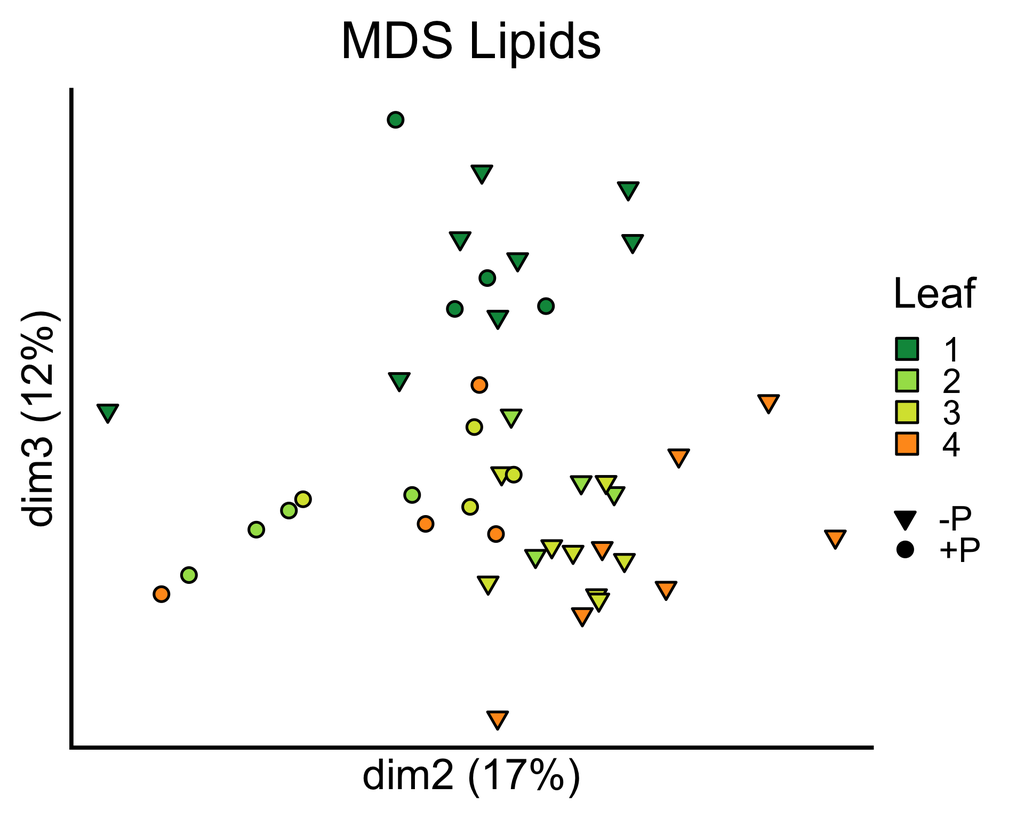

```r
print(lipid_MDS_23)
```

## MDS: Dimensions 3 and 4

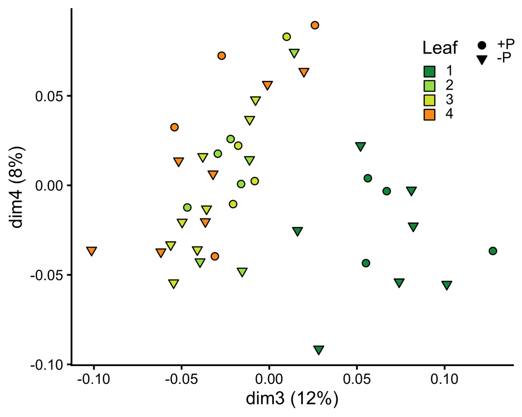

```r
d %>%
  mutate(leaf = factor(leaf_tissue)) %>%
  ggplot(aes(x = dim3, y = dim4, fill = leaf, shape = Treatment)) +
  xlab(paste0("dim3 (", round(100 * mds$var.explained[3]), "%)")) +
  ylab(paste0("dim4 (", round(100 * mds$var.explained[4]), "%)")) +
  geom_point(size = 4) +
  scale_fill_manual(values = green_to_orange) +
  scale_shape_manual(values = c(21, 25)) +
  guides(
    shape = guide_legend(
      title = element_blank(),
      override.aes = list(fill = "black")
    ),
    fill = guide_legend(
      title = "Leaf",
      order = 2,
      override.aes = list(geom = "point", shape = 22, size = 7, reverse = TRUE)
    )
  ) +
  theme_classic2(base_size = 25) +
  theme(
    legend.box = "horizontal",
    legend.position = c(0.9, 0.8),
    legend.text = element_markdown(),
    legend.spacing = unit(0, "line"),
    legend.box.spacing = unit(0, "line")
  )
```

## MDS Correlation Analysis

**Purpose**: Quantify relationships between MDS dimensions and experimental factors.

```r
mds_cor_results <- tibble(
  dimension = c("Dim2", "Dim3", "Dim4"),
  factor = c("Treatment", "Leaf tissue", "Leaf tissue"),
  correlation = c(
    cor(d$dim2, as.numeric(d$Treatment)),
    cor(d$dim3, as.numeric(d$leaf_tissue)),
    cor(d$dim4, as.numeric(d$leaf_tissue))
  ),
  p_value = c(
    cor.test(d$dim2, as.numeric(d$Treatment))$p.value,
    cor.test(d$dim3, d$leaf_tissue)$p.value,
    cor.test(d$dim4, d$leaf_tissue)$p.value
  )
) %>%
  mutate(
    adj_p_value = p.adjust(p_value, method = "fdr"),
    correlation = round(correlation, 3),
    p_value = signif(p_value, 3),
    adj_p_value = signif(adj_p_value, 3)
  )

print(mds_cor_results)
```

```
## # A tibble: 3 × 5
##   dimension factor      correlation      p_value adj_p_value
##   <chr>     <chr>             <dbl>        <dbl>       <dbl>
## 1 Dim2      Treatment         0.54  0.000185      0.000277
## 2 Dim3      Leaf tissue      -0.733 0.0000000233  0.00000007
## 3 Dim4      Leaf tissue       0.346 0.0231        0.0231
```

# Differential Abundance Analysis

## Design Matrix

**Purpose**: Construct design matrix incorporating biological factors and technical covariates.

**Approach**: Model includes: - Spatial covariates: Plot_Row (field position) - Technical covariate: injection_order (MS drift) - Biological factors: leaf_tissue (centered), Treatment, Genotype - Interactions: leaf_tissue × Treatment, Genotype × Treatment, leaf_tissue × Genotype

```r
d$Treatment <- factor(d$Treatment, levels = c("+P", "-P"))
d$leaf_tissue_c <- scale(d$leaf_tissue, center = TRUE, scale = FALSE)

design <- model.matrix(
  ~ Plot_Row + injection_order + leaf_tissue_c * Treatment +
    Genotype * Treatment + leaf_tissue_c * Genotype,
  d
)

cat("Design matrix dimensions:", dim(design), "\n")
```

```
## Design matrix dimensions: 43 9
```

```r
cat("\nCoefficients in model:\n")
```

```
##
## Coefficients in model:
```

```r
print(colnames(design))
```

```
## [1] "(Intercept)"                 "Plot_Row"
## [3] "injection_order"             "leaf_tissue_c"
## [5] "Treatment-P"                 "GenotypeINV4m"
## [7] "leaf_tissue_c:Treatment-P"   "Treatment-P:GenotypeINV4m"
## [9] "leaf_tissue_c:GenotypeINV4m"
```

## Voom Transformation

**Purpose**: Model mean-variance relationship and calculate precision weights for linear modeling.

**Approach**: Apply voom without additional normalization since data is already TIC (Total Ion current) normalized.

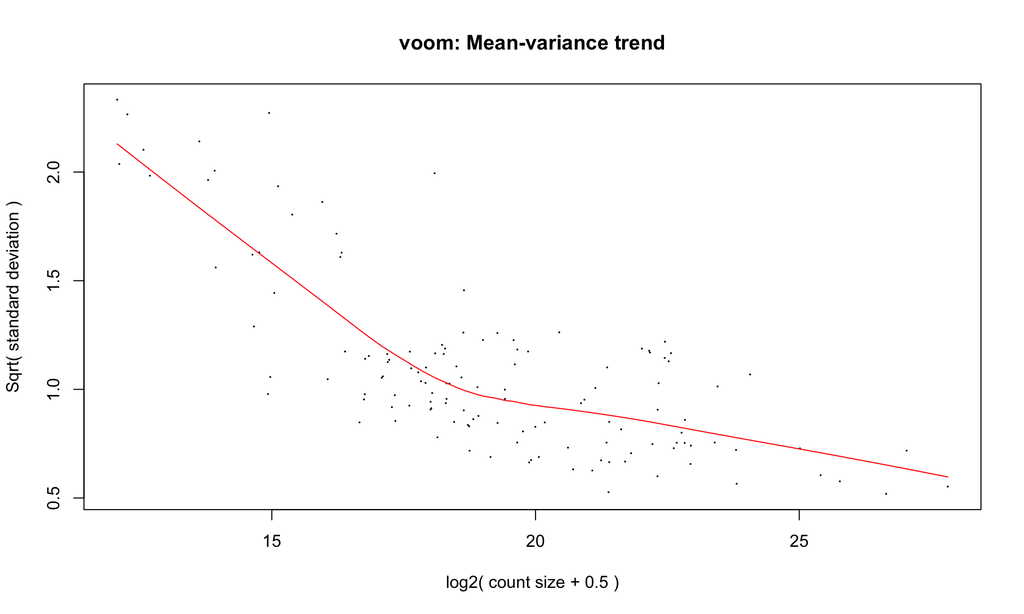

```r
voomR <- voom(y_ion, design = design, normalize.method = "none", plot = TRUE)
```

```r
cat("Voom transformation complete\n")
```

```
## Voom transformation complete
```

## Estimate Block Correlation

**Purpose**: Account for within-block correlation from field design.

**Approach**: Define blocks as Treatment × Plot_Column interaction and estimate consensus correlation.

```r
block <- interaction(d$Treatment, d$Plot_Column)

corfit <- duplicateCorrelation(voomR, design, block = block)

cat("Consensus correlation:", corfit$consensus.correlation, "\n")
```

```
## Consensus correlation: 0.05080766
```

## Fit Linear Model

**Purpose**: Fit linear model for each lipid accounting for block structure.

```r
fit <- lmFit(voomR, design, block = block,
             correlation = corfit$consensus.correlation)

ebfit <- eBayes(fit)

cat("Model fitted:", nrow(fit$coefficients), "lipids ×",
    ncol(fit$coefficients), "coefficients\n")
```

```
## Model fitted: 132 lipids × 9 coefficients
```

```r
cat("\nSignificant lipids per coefficient (FDR < 0.05):\n")
```

```
##
## Significant lipids per coefficient (FDR < 0.05):
```

```r
print(colSums(abs(decideTests(ebfit))))
```

```
##                 (Intercept)                    Plot_Row
##                         121                           0
##             injection_order               leaf_tissue_c
##                          42                           8
##                 Treatment-P               GenotypeINV4m
##                          40                           0
##   leaf_tissue_c:Treatment-P   Treatment-P:GenotypeINV4m
##                           2                           0
## leaf_tissue_c:GenotypeINV4m
##                           0
```

# Extract Results

## Extract Predictor Effects

**Purpose**: Extract differential abundance statistics for biological predictors of interest.

```r
#' Extract differential expression results for specified predictors
#'
#' @param ebfit An eBayes fitted model object from limma
#' @param predictor_map Named vector mapping coefficient names to display names
#'
#' @return Data frame with DE results for all specified predictors
extract_predictor_effects <- function(ebfit, predictor_map) {
  coef_names <- colnames(coef(ebfit))
  coef_indices <- match(names(predictor_map), coef_names)

  if (any(is.na(coef_indices))) {
    missing <- names(predictor_map)[is.na(coef_indices)]
    stop("Coefficients not found: ", paste(missing, collapse = ", "),
         "\nAvailable: ", paste(coef_names, collapse = ", "))
  }

  result_list <- lapply(seq_along(coef_indices), function(i) {
    idx <- coef_indices[i]
    tt <- topTable(ebfit, coef = idx, sort.by = "none", n = Inf)

    crit_value <- qt(0.975, ebfit$df.residual + ebfit$df.prior)
    std_errors <- ebfit$stdev.unscaled[, idx] * sqrt(ebfit$s2.post)

    tt$upper <- tt$logFC + crit_value * std_errors
    tt$lower <- tt$logFC - crit_value * std_errors
    tt$predictor <- predictor_map[i]
    tt$response <- rownames(tt)
    tt$std_err <- std_errors
    tt
  })

  results <- do.call(rbind, result_list)
  rownames(results) <- NULL

  results %>%
    select(predictor, response, everything()) %>%
    arrange(adj.P.Val)
}
```

## Map Coefficients to Predictors

```r
predictor_map <- c(
  "leaf_tissue_c" = "Leaf",
  "Treatment-P" = "-P",
  "leaf_tissue_c:Treatment-P" = "Leaf:-P"
)

cat("Available coefficients:\n")
```

```
## Available coefficients:
```

```r
print(colnames(coef(ebfit)))
```

```
## [1] "(Intercept)"                 "Plot_Row"
## [3] "injection_order"             "leaf_tissue_c"
## [5] "Treatment-P"                 "GenotypeINV4m"
## [7] "leaf_tissue_c:Treatment-P"   "Treatment-P:GenotypeINV4m"
## [9] "leaf_tissue_c:GenotypeINV4m"
```

```r
effects_df <- extract_predictor_effects(ebfit, predictor_map)

cat("\nTotal tests:", nrow(effects_df), "\n")
```

```
##
## Total tests: 396
```

```r
cat("Tests per predictor:\n")
```

```
## Tests per predictor:
```

```r
print(table(effects_df$predictor))
```

```
##
##      -P    Leaf Leaf:-P
##     132     132     132
```

```r
cat("\nSignificant per predictor (FDR < 0.05):\n")
```

```
##
## Significant per predictor (FDR < 0.05):
```

```r
print(table(effects_df$predictor[effects_df$adj.P.Val < 0.05]))
```

```
##
##      -P    Leaf Leaf:-P
##      40       8       2
```

## Classify Differential Lipids

**Purpose**: Apply two-tier classification system for differential lipids.

**Approach**: - Tier 1: Significant (FDR < 0.05) - Tier 2: Strong (significant + effect size threshold)

Effect size thresholds: - Leaf predictors: |logFC| > 0.5 - Categorical predictors: |logFC| > 1.5

```r
#' Classify differential lipids with predictor-specific thresholds
classify_differential_lipids <- function(effects_df) {
  leaf_predictors <- c("Leaf", "Leaf:-P")

  effects_df %>%
    mutate(
      is_DL = adj.P.Val < 0.05,
      is_strong_DL = case_when(
        predictor %in% leaf_predictors & is_DL & abs(logFC) > 0.5 ~ TRUE,
        predictor == "-P" & is_DL & abs(logFC) > 1.5 ~ TRUE,
        .default = FALSE
      ),
      regulation = case_when(
        !is_strong_DL ~ "Not significant",
        logFC > 0 ~ "Upregulated",
        logFC < 0 ~ "Downregulated",
        TRUE ~ "Not significant"
      ),
      neglogP = -log10(adj.P.Val),
      label = if_else(is_DL, response, "")
    )
}

effect_order <- c("Leaf", "-P", "Leaf:-P")

effects_df <- effects_df %>%
  mutate(predictor = factor(predictor, levels = effect_order)) %>%
  classify_differential_lipids()

effects_df$label <- sub("_", "", effects_df$label, perl = TRUE)
effects_df$label <- sub("_", ":", effects_df$label, perl = TRUE)
```

## Summary Statistics

```r
cat("=== Classification Summary ===\n")
```

```
## === Classification Summary ===
```

```r
cat("Total tests:", nrow(effects_df), "\n\n")
```

```
## Total tests: 396
```

```r
cat("Tier 1 - Significant DLs (FDR < 0.05):\n")
```

```
## Tier 1 - Significant DLs (FDR < 0.05):
```

```r
print(table(effects_df$predictor, effects_df$is_DL))
```

```
##
##           FALSE TRUE
##   Leaf      124    8
##   -P         92   40
##   Leaf:-P   130    2
```

```r
cat("\nTier 2 - Strong DLs:\n")
```

```
##
## Tier 2 - Strong DLs:
```

```r
print(table(effects_df$predictor, effects_df$is_strong_DL))
```

```
##
##           FALSE TRUE
##   Leaf      124    8
##   -P        105   27
##   Leaf:-P   130    2
```

```r
cat("\nDirection of significant effects:\n")
```

```
##
## Direction of significant effects:
```

```r
print(with(effects_df %>% filter(is_DL),
           table(predictor, regulation)))
```

```
##          regulation
## predictor Downregulated Not significant Upregulated
##   Leaf                3               0           5
##   -P                 12              13          15
##   Leaf:-P             1               0           1
```

# Export Results

```r
write.csv(
  effects_df,
  file = file.path(paths$intermediate, "lipid_differential_abundance_TIC_normalized.csv"),
  row.names = FALSE
)

write.csv(
  molar_ion_fractions,
  file = file.path(paths$intermediate, "lipid_molar_ion_fractions.csv"),
  row.names = TRUE
)

write.csv(
  voomR$E,
  file = file.path(paths$intermediate, "voom_log2_TIC_normalized_lipids.csv"),
  row.names = TRUE
)

cat("=== Analysis Complete ===\n")
cat("Results exported to intermediate/\n")
```

# Volcano Plots

## Custom Legend Function

**Purpose**: Create custom legend key displaying line segments instead of points.

```r
#' Custom key glyph for legend
#'
#' @param data Aesthetic data for the legend key
#' @param params Additional parameters
#' @param size Size of the key
#'
#' @return A grid grob object
draw_key_custom <- function(data, params, size) {
  colour <- data$colour
  data <- data[data$colour == colour, ]
  grid::segmentsGrob(
    0, 1 / 2, 1, 1 / 2,
    gp = grid::gpar(
      col = data$colour,
      lwd = data$linewidth * 4
    )
  )
}
```

## Prepare Plot Data

**Purpose**: Join differential abundance results with lipid class annotations.

```r
plot_data <- effects_df %>%
  droplevels() %>%
  inner_join(sp, by = c(response = "colname"))

label_data <- plot_data %>%
  filter(is_strong_DL)

force <- 1
label_size <- 6
base_size <- 30
```

## Three-Panel Volcano Plot

**Purpose**: Visualize differential abundance across all three predictors with faceted layout.

**Approach**: Create volcano plots for Leaf, -P, and Leaf:-P predictors with staged label placement to avoid overlaps. Downregulated lipids labeled on left, upregulated on right.

**Expected outcome**: Publication-quality three-panel figure showing effect sizes and significance levels with lipid class color coding.

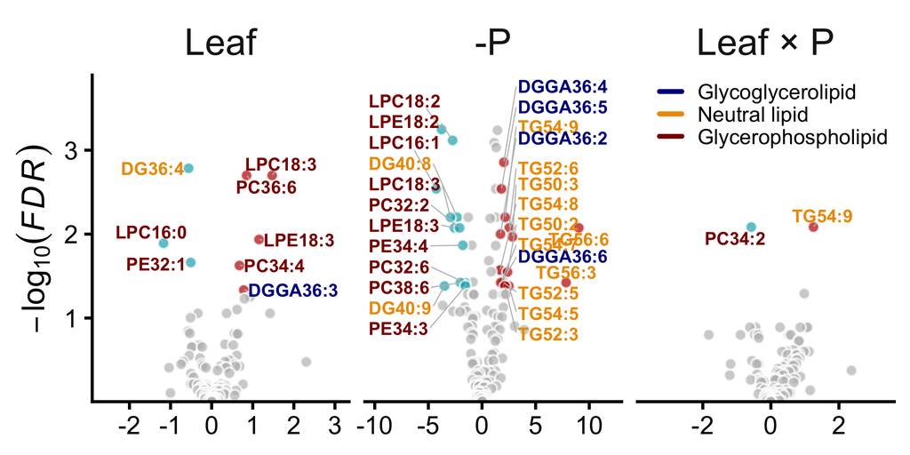

```r
force <- 3

predictor_labels <- c( "Leaf", "-P", "Leaf × P")
names(predictor_labels) <- levels(plot_data$predictor)


lipid_volcano_3 <- plot_data %>%
  ggplot(aes(
    x = logFC,
    y = -log10(adj.P.Val),
    color = head_group,
    fill = regulation,
    label = label
  )) +
  ylab(expression(-log[10](italic(FDR)))) +
  xlab(expression(log[2]("Fold Change"))) +
  geom_point(alpha = 0.7, shape = 21, color = "white") +
  scale_fill_manual(
    name = "",
    values = c("#00AFBB", "grey", "#bb0c00"),
    labels = c("Downregulated", "Not significant", "Upregulated")
  ) +
  geom_text_repel(
    data = label_data %>%
      filter(predictor == "Leaf", regulation == "Downregulated",
             !is.na(label), label != ""),
    force = force,
    fontface = "bold",
    size = label_size,
    segment.color = "grey",
    min.segment.length = 0,
    xlim = c(NA, -0.5),
    max.overlaps = 20,
    key_glyph = draw_key_custom
  ) +
  geom_text_repel(
    data = label_data %>%
      filter(predictor == "Leaf", regulation == "Upregulated",
             !is.na(label), label != ""),
    force = force,
    fontface = "bold",
    size = label_size,
    segment.color = "grey",
    min.segment.length = 0,
    xlim = c(0.5, NA),
    #max.overlaps = 20,
    key_glyph = draw_key_custom
  ) +
  geom_text_repel(
    data = label_data %>%
      filter(predictor == "-P", regulation == "Downregulated",
             !is.na(label), label != ""),
    force = force,
    fontface = "bold",
    size = label_size,
    direction = "y",
    segment.color = "grey",
    xlim = c(NA, -5),
    #max.overlaps = 0,
    key_glyph = draw_key_custom
  ) +
  geom_text_repel(
    data = label_data %>%
      filter(predictor == "-P", regulation == "Upregulated",
             !is.na(label), label != ""),
    force = force,
    fontface = "bold",
    size = label_size,
    direction = "y",
    segment.color = "grey",
    xlim = c(3, NA),
    max.overlaps = 20,
    key_glyph = draw_key_custom
  ) +
  geom_text_repel(
    data = label_data %>%
      filter(predictor == "Leaf:-P", !is.na(label), label != ""),
    force = force,
    fontface = "bold",
    size = label_size,
    segment.color = "grey",
    min.segment.length = 0,
    max.overlaps = 2,
    key_glyph = draw_key_custom
  ) +
  scale_color_manual(
    name = "",
    values = c("darkblue", "orange2", "darkred"),
    labels = c("Glycoglycerolipid", "Neutral lipid", "Glycerophospholipid")
  ) +
  facet_wrap(. ~ predictor,
             labeller = labeller(predictor = predictor_labels),
             scales = "free_x", ncol = 3) +
  guides(
    color = guide_legend(override.aes = list(linewidth = 1.5)),
    fill = "none"
  ) +
  scale_y_continuous(expand = expansion(mult = c(0, 0.2))) +
  scale_x_continuous(expand = expansion(mult = c(0.5, 0.3))) +
  theme_classic2(base_size = base_size) +
  theme(
    plot.title = element_blank(),
    strip.text = element_markdown(size = 35),
    strip.background = element_blank(),
    legend.position = c(0.85, 0.95),
    legend.background = element_rect(fill = "transparent"),
    axis.title.x = element_blank(),
    legend.spacing = unit(0, "line"),
    legend.box.spacing = unit(0, "line"),
    legend.text = element_text(size = 20),
    axis.title.y = element_text(margin = margin(r = 5,"pt")),
    # plot.margin = margin(5.5, 5.5, 0, 5.5, "pt"),
  )
ggsave(
  filename = file.path(paths$figures, "lipid_volcano_3_TIC.png"),
  plot = lipid_volcano_3,
  height = 6,
  width = 12,
  units = "in",
  dpi = 150
)

saveRDS(lipid_volcano_3, file.path(paths$intermediate, "lipid_volcano_3_TIC.rds"))

print(lipid_volcano_3)
```

## Two-Panel Volcano Plot

**Purpose**: Focused visualization of Leaf and -P effects without interaction term.

**Approach**: Subset to primary biological predictors and create two-panel layout with optimized label placement.

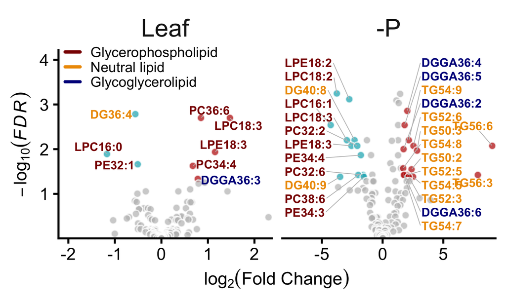

```r
plot_data_2 <- effects_df %>%
  filter(predictor != "Leaf:-P") %>%
  droplevels() %>%
  inner_join(sp, by = c(response = "colname"))

volcano_2 <- plot_data_2 %>%
  ggplot(aes(
    x = logFC,
    y = -log10(adj.P.Val),
    color = head_group,
    fill = regulation,
    label = label
  )) +
  ylab(expression(-log[10](italic(FDR)))) +
  xlab(expression(log[2]("Fold Change"))) +
  geom_point(alpha = 0.7, shape = 21, color = "white") +
  scale_fill_manual(
    name = "",
    values = c("#00AFBB", "grey", "#bb0c00"),
    labels = c("Downregulated", "Bellow threshold", "Upregulated")
  ) +
  geom_text_repel(
    data = label_data %>%
      filter(predictor == "Leaf", regulation == "Downregulated",
             !is.na(label), label != ""),
    force = force,
    fontface = "bold",
    size = label_size,
    segment.color = "grey",
    min.segment.length = 0,
    xlim = c(NA, -0.5),
    max.overlaps = 20,
    key_glyph = draw_key_custom
  ) +
  geom_text_repel(
    data = label_data %>%
      filter(predictor == "Leaf", regulation == "Upregulated",
             !is.na(label), label != ""),
    force = force,
    fontface = "bold",
    size = label_size,
    segment.color = "grey",
    min.segment.length = 0,
    xlim = c(0.5, NA),
    #max.overlaps = 20,
    key_glyph = draw_key_custom
  ) +
  geom_text_repel(
    data = label_data %>%
      filter(predictor == "-P", regulation == "Downregulated",
             !is.na(label), label != ""),
    force = force,
    fontface = "bold",
    size = label_size,
    direction = "y",
    segment.color = "grey",
    xlim = c(NA, -5),
    #max.overlaps = 0,
    key_glyph = draw_key_custom
  ) +
  geom_text_repel(
    data = label_data %>%
      filter(predictor == "-P", regulation == "Upregulated",
             !is.na(label), label != ""),
    force = force,
    fontface = "bold",
    size = label_size,
    direction = "y",
    segment.color = "grey",
    xlim = c(3, NA),
    max.overlaps = 20,
    key_glyph = draw_key_custom
  ) +
  scale_color_manual(
    name = "",
    values = c("darkblue", "orange2", "darkred"),
    labels = c("Glycoglycerolipid", "Neutral lipid", "Glycerophospholipid")
  ) +
  facet_wrap(. ~ predictor, scales = "free_x", ncol = 3) +
  guides(
    color = guide_legend(override.aes = list(linewidth = 1.5),
                         reverse = TRUE),
    fill = "none"
  ) +
  scale_y_continuous(expand = expansion(mult = c(0, 0.3))) +
  scale_x_continuous(expand = expansion(mult = c(0.3, 0.02))) +
  theme_classic2(base_size = base_size) +
  theme(
    plot.title = element_blank(),
    strip.text = element_markdown(size = 35),
    strip.background = element_blank(),
    axis.title = element_text(size = 25),
    legend.position = c(0.19, 0.99),
    legend.background = element_rect(fill = "transparent"),
    legend.spacing = unit(0, "line"),
    legend.box.spacing = unit(0, "line"),
    legend.text = element_text(size = 20),
  )

print(volcano_2)
```

```r
saveRDS(volcano_2, file.path(paths$intermediate, "lipid_volcano_2_TIC.rds"))
ggsave(
  filename = file.path(paths$figures, "lipid_volcano_2_TIC.png"),
  plot = volcano_2,
  height = 6,
  width = 10,
  units = "in",
  dpi = 150
)
```

## One-Panel Volcano Plot: Interaction Term

**Purpose**: Highlight lipids showing differential response to phosphorus treatment across leaf developmental stages.

**Approach**: Isolate Leaf:-P interaction term and create single volcano plot without x-axis label restrictions.

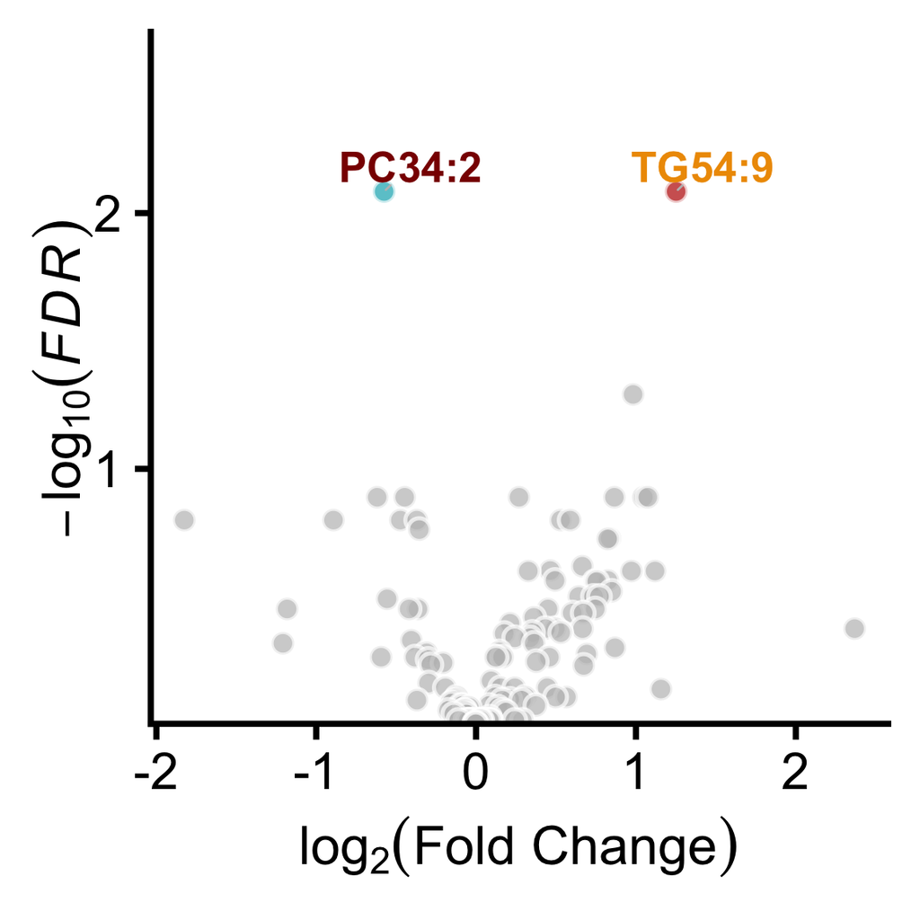

```r
plot_data_leafP <- effects_df %>%
  filter(predictor == "Leaf:-P") %>%
  droplevels() %>%
  inner_join(sp, by = c(response = "colname"))

volcano_leafP <- plot_data_leafP %>%
  ggplot(aes(
    x = logFC,
    y = -log10(adj.P.Val),
    color = head_group,
    fill = regulation,
    label = label
  )) +
  ylab(expression(-log[10](italic(FDR)))) +
  xlab(expression(log[2]("Fold Change"))) +
  ylim(0, 5) +
  geom_point(alpha = 0.7, shape = 21, color = "white") +
  scale_fill_manual(
    name = "",
    values = c("#00AFBB", "grey", "#bb0c00"),
    labels = c("Downregulated", "Bellow threshold", "Upregulated")
  ) +
  geom_text_repel(
    data = plot_data_leafP %>%
      filter(regulation == "Downregulated", !is.na(label), label != ""),
    force = force,
    fontface = "bold",
    size = 7,
    segment.color = "grey",
    min.segment.length = 0,
    max.overlaps = 20,
    key_glyph = draw_key_custom
  ) +
  geom_text_repel(
    data = plot_data_leafP %>%
      filter(regulation == "Upregulated", !is.na(label), label != ""),
    force = force,
    fontface = "bold",
    size = 7,
    segment.color = "grey",
    min.segment.length = 0,
    max.overlaps = 20,
    key_glyph = draw_key_custom
  ) +
  scale_color_manual(
    name = "",
    values = c("orange2", "darkred", "darkblue"),
    labels = c("Glycolipid", "Neutral lipid", "Phospholipid")
  ) +
  guides(
    color = guide_legend(override.aes = list(linewidth = 1.5),
                         reverse = TRUE),
    fill = "none"
  ) +
  scale_y_continuous(expand = expansion(mult = c(0, 0.3))) +
  theme_classic2(base_size = base_size) +
  theme(
    plot.title = element_blank(),
    strip.text = element_markdown(size = 35),
    legend.position = "none",
    legend.background = element_rect(fill = "transparent"),
    axis.title = element_text(size = 25),
    legend.spacing = unit(0, "line"),
    legend.box.spacing = unit(0, "line"),
    legend.text = element_text(size = 20),
    axis.title.y = element_text(margin = margin(r = -5)),
    strip.background = element_blank()
  )

print(volcano_leafP)
```

```r
ggsave(
  filename = file.path(paths$figures, "lipid_volcano_leafP_TIC.png"),
  plot = volcano_leafP,
  height = 7,
  width = 7,
  units = "in",
  dpi = 150
)
```

## Export Strong Lipids

```r
write.csv(
  label_data,
  file = file.path(paths$intermediate, "strong_DLs_TIC.csv"),
  row.names = FALSE
)

cat("Volcano plots saved to figures/\n")
```

```
## Volcano plots saved to figures/
```

```r
cat("Strong lipids saved to intermediate/\n")
```

```
## Strong lipids saved to intermediate/
```

# Interaction Plots: Leaf × Phosphorus

## Identify Leaf:-P Interaction Lipids

**Purpose**: Extract strong lipids showing significant interaction between leaf developmental stage and phosphorus treatment.

```r
interaction_lipids <- effects_df %>%
  filter(predictor == "Leaf:-P", is_strong_DL) %>%
  arrange(adj.P.Val)

cat("Strong Leaf:-P interaction lipids:",
    nrow(interaction_lipids), "\n")
```

```
## Strong Leaf:-P interaction lipids: 2
```

```r
print(interaction_lipids %>%
        select(response, logFC, adj.P.Val, regulation))
```

```
##   response      logFC   adj.P.Val    regulation
## 1  PC_34_2 -0.5753961 0.008235879 Downregulated
## 2  TG_54_9  1.2513465 0.008235879   Upregulated
```

```r
interaction_lipid_ids <- interaction_lipids$response
```

## Data Transformation for Visualization

**Purpose**: Convert analysis-ready data back to biologically interpretable units for visualization.

**Approach**: The statistical analysis uses voom-normalized log2(CPM) values. For visualization, we convert these back to total ion current (TIC) fractions, which represent each lipid’s proportion of the total detected lipid pool.

**Three possible input formats**: 1. **Raw counts**: Peak areas directly from MS-DIAL 2. **TIC fractions**: Proportions summing to 1.0 per sample (molar ion fractions) 3. **log2(CPM)**: Voom-normalized values used in statistical models

```r
cat("=== Available Data Formats ===\n")
```

```
## === Available Data Formats ===
```

```r
cat("1. Raw counts (y$counts): Peak areas from MS detector\n")
```

```
## 1. Raw counts (y$counts): Peak areas from MS detector
```

```r
cat("2. TIC fractions: Proportions of total signal per sample\n")
```

```
## 2. TIC fractions: Proportions of total signal per sample
```

```r
cat("3. log2(CPM) (voomR$E): Voom-normalized for statistics\n\n")
```

```
## 3. log2(CPM) (voomR$E): Voom-normalized for statistics
```

```r
cat("Statistical analysis used:", class(voomR$E), "\n")
```

```
## Statistical analysis used: matrix array
```

```r
cat("For visualization, we convert to TIC fractions\n")
```

```
## For visualization, we convert to TIC fractions
```

## Conversion Functions

**Purpose**: Provide explicit functions to convert between data formats.

```r
#' Convert raw counts to TIC fractions
#'
#' @param count_matrix Matrix with raw peak areas (lipids × samples)
#'
#' @return Matrix of TIC fractions (0-1 scale)
counts_to_TIC_fraction <- function(count_matrix) {
  TIC_fractions <- sweep(count_matrix, 2, colSums(count_matrix), FUN = "/")

  sample_sums <- colSums(TIC_fractions)
  if (!all(abs(sample_sums - 1) < 1e-10)) {
    warning("TIC fractions don't sum to 1. Range: ",
            paste(range(sample_sums), collapse = " - "))
  }

  TIC_fractions
}

#' Convert log2(CPM) to TIC fractions
#'
#' @param log2_cpm_matrix Matrix with log2(CPM) values from voom
#' @param pseudo_count Pseudo-count added before log transformation
#'
#' @return Matrix of TIC fractions (0-1 scale)
log2cpm_to_TIC_fraction <- function(log2_cpm_matrix, pseudo_count = 1e-9) {
  # Back-transform from log2(CPM)
  cpm <- 2^log2_cpm_matrix - pseudo_count

  # CPM to counts (proportional, scaling doesn't matter for fractions)
  # Since CPM = (counts/library_size) * 1e6
  # We can work directly with CPM as pseudo-counts
  counts_proxy <- cpm

  # Convert to TIC fractions
  TIC_fractions <- sweep(counts_proxy, 2, colSums(counts_proxy), FUN = "/")

  TIC_fractions
}

#' Convert TIC fractions to log10 for visualization
#'
#' @param TIC_fraction_matrix Matrix of TIC fractions (0-1 scale)
#' @param offset Small value to avoid log(0)
#'
#' @return Matrix of log10(TIC fraction)
TIC_fraction_to_log10 <- function(TIC_fraction_matrix, offset = 1e-9) {
  log10(TIC_fraction_matrix + offset)
}
```

## Apply Conversions

**Purpose**: Transform voom-normalized data to TIC fractions for interpretable visualization.

**Approach**: 1. Start with voomR$E (log2 CPM from statistical analysis) 2. Back-transform to pseudo-counts 3. Convert to TIC fractions (proportions) 4. Apply log10 transformation for plotting

```r
cat("=== Data Transformation Pipeline ===\n")
```

```
## === Data Transformation Pipeline ===
```

```r
cat("Input: voomR$E (log2 CPM)\n")
```

```
## Input: voomR$E (log2 CPM)
```

```r
# Step 1: Convert log2(CPM) to TIC fractions
TIC_fraction <- log2cpm_to_TIC_fraction(
  log2_cpm_matrix = voomR$E,
  pseudo_count = 0
)

cat("Intermediate: TIC fractions\n")
```

```
## Intermediate: TIC fractions
```

```r
cat("  Range:", range(TIC_fraction, na.rm = TRUE), "\n")
```

```
##   Range: 5e-10 0.3637006
```

```r
cat("  Sample sums:",
    range(colSums(TIC_fraction, na.rm = TRUE)), "\n")
```

```
##   Sample sums: 1 1
```

```r
# Step 2: Log10 transform for visualization
log10_TIC <- TIC_fraction_to_log10(
  TIC_fraction_matrix = TIC_fraction,
  offset = 1e-9
)

cat("Output: log10(TIC fraction)\n")
```

```
## Output: log10(TIC fraction)
```

```r
cat("  Range:", range(log10_TIC, na.rm = TRUE), "\n")
```

```
##   Range: -8.823909 -0.4392559
```

## Plotting Function: Lipid Trajectories

**Purpose**: Visualize lipid abundance trajectories across leaf stages, separated by phosphorus treatment.

```r
#' Plot lipid trajectories by treatment
#'
#' @param lipid_data Matrix or data frame with lipid abundances
#'   Can be: log10(TIC fraction), log2(CPM), or TIC fraction
#' @param lipid_ids Character vector of lipid IDs to plot
#' @param metadata Data frame with sample information (tube, leaf_tissue,
#'   Treatment columns required)
#' @param data_type Character: "log10_TIC", "log2_CPM", or "TIC_fraction"
#'
#' @return ggplot object with treatment-colored trajectories
plot_lipid_by_treatment <- function(lipid_data,
                                     lipid_ids,
                                     metadata,
                                     data_type = "log10_TIC") {

  # Validate data type
  stopifnot(
    data_type %in% c("log10_TIC", "log2_CPM", "TIC_fraction")
  )

  # Extract and format data
  plot_data <- lipid_data %>%
    as.data.frame() %>%
    tibble::rownames_to_column("lipid") %>%
    filter(lipid %in% lipid_ids) %>%
    pivot_longer(
      cols = -lipid,
      names_to = "tube",
      values_to = "abundance"
    ) %>%
    left_join(
      metadata %>% select(tube, leaf_tissue, Treatment),
      by = "tube"
    ) %>%
    filter(!is.na(Treatment)) %>%
    mutate(
      Treatment = factor(
        Treatment,
        levels = c("High_P", "Low_P"),
        labels = c("+P", "-P")
      )
    )

  # Format lipid labels: PC_34_2 -> PC 34:2
  plot_data$lipid_label <- sub("_", "", plot_data$lipid, perl = TRUE)
  plot_data$lipid_label <- sub("_", ":", plot_data$lipid_label, perl = TRUE)

  # Maintain input order
  lipid_levels <- sub("_", "", lipid_ids, perl = TRUE)
  lipid_levels <- sub("_", ":", lipid_levels, perl = TRUE)

  plot_data$lipid_label <- factor(
    plot_data$lipid_label,
    levels = lipid_levels
  )

  # Calculate summary statistics
  summary_data <- plot_data %>%
    group_by(lipid, lipid_label, leaf_tissue, Treatment) %>%
    summarise(
      mean = mean(abundance, na.rm = TRUE),
      se = sd(abundance, na.rm = TRUE) / sqrt(n()),
      .groups = "drop"
    )

  # Set y-axis label based on input data type
  y_label <- switch(
    data_type,
    "log10_TIC" = expression(log[10]("TIC fraction")),
    "log2_CPM" = expression(log[2]("CPM")),
    "TIC_fraction" = "TIC fraction"
  )

  # Plot parameters
  base_size <- 35
  pd <- position_dodge(width = 0.2)

  # Create plot
  summary_data %>%
    ggplot(aes(
      x = leaf_tissue,
      y = mean,
      color = Treatment,
      fill = Treatment,
      linetype = Treatment,
      shape = Treatment,
      group = Treatment
    )) +
    geom_line(linewidth = 1.5) +
    geom_point(position = pd, size = 5) +
    geom_errorbar(
      aes(ymin = mean - se, ymax = mean + se),
      position = pd,
      width = 0.2,
      linewidth = 1,
      linetype = "solid"
    ) +
    scale_color_manual(
      values = c("+P" = "gold", "-P" = "purple4")
    ) +
    scale_fill_manual(
      values = c("+P" = "gold", "-P" = "purple4")
    ) +
    scale_linetype_manual(
      values = c("+P" = "solid", "-P" = "dashed")
    ) +
    scale_shape_manual(
      values = c("+P" = 19, "-P" = 25)
    ) +
    facet_wrap(~ lipid_label, scales = "free_y", ncol = 2) +
    labs(
      x = "Leaf",
      y = y_label
    ) +
    scale_y_continuous(
      expand = expansion(add = c(0.1, 0.1))
    ) +
    guides(
      fill = "none",
      linetype = "none",
      shape = guide_legend(
        override.aes = list(
          fill = c("gold","purple4"),
          color= c("gold","purple4"),
          linetype = "solid",
          size = 5)
      ),
    ) +
    theme_classic(base_size = base_size) +
    theme(
      strip.background = element_blank(),
      strip.text = element_text(face = "bold", size = 25),
      # legend.position = c(0.1, 0.95),
      legend.title = element_blank(),
      legend.background = element_rect(fill = "transparent")
    )
}
```

## Plot Leaf:-P Interaction Lipids

**Approach**: Plot log10(TIC fraction) to show proportions on interpretable scale. Divergent trajectories between treatments indicate interaction.

**Expected outcome**: Treatment-specific responses across leaf developmental gradient, revealing context-dependent regulation.

```r
#' Create horizontal 6-panel lipid trajectory plot with lipid class colors
#'
#' @param lipid_data Matrix with lipid abundances (log10 TIC fraction)
#' @param effects_df Data frame with differential abundance results
#' @param metadata Sample metadata with tube, leaf_tissue, Treatment
#' @param sp Data frame with lipid class annotations
#' @param data_type Character indicating input data format
#'
#' @return ggplot object with 6-panel horizontal layout
create_trajectory_6panel <- function(lipid_data,
                                      effects_df,
                                      metadata,
                                      sp,
                                      data_type = "log10_TIC",
                                     nrow=1,
                                     ncol=6) {

  # Select top lipid per predictor×regulation combination
  selected_lipids <- effects_df %>%
    filter(is_strong_DL) %>%
    group_by(predictor, regulation) %>%
    slice_min(adj.P.Val, n = 1, with_ties = FALSE) %>%
    ungroup() %>%
    mutate(
      panel_label = case_when(
        predictor == "Leaf" & regulation == "Downregulated" ~ "Leaf Down",
        predictor == "Leaf" & regulation == "Upregulated" ~ "Leaf Up",
        predictor == "-P" & regulation == "Downregulated" ~ "-P Down",
        predictor == "-P" & regulation == "Upregulated" ~ "-P Up",
        predictor == "Leaf:-P" & regulation == "Downregulated" ~
          "Negative\nLeaf × -P",
        predictor == "Leaf:-P" & regulation == "Upregulated" ~
          "Positive\nLeaf × -P"
      )
    ) %>%
    arrange(predictor, desc(regulation)) %>%
    select(response, predictor, regulation, panel_label, logFC, adj.P.Val)

  # Join with lipid class annotations
  selected_lipids <- selected_lipids %>%
    left_join(sp, by = c("response" = "colname"))

  # Format lipid labels for titles
  selected_lipids$lipid_label <- sub("_", "", selected_lipids$response,
                                       perl = TRUE)
  selected_lipids$lipid_label <- sub("_", ":", selected_lipids$lipid_label,
                                       perl = TRUE)

  # Combine panel label with lipid name
  selected_lipids$full_label <- paste0(selected_lipids$panel_label, "\n",
                                        selected_lipids$lipid_label)

  # Extract abundances and join with metadata
  plot_data <- lipid_data %>%
    as.data.frame() %>%
    tibble::rownames_to_column("lipid") %>%
    filter(lipid %in% selected_lipids$response) %>%
    pivot_longer(
      cols = -lipid,
      names_to = "tube",
      values_to = "abundance"
    ) %>%
    left_join(
      metadata %>% select(tube, leaf_tissue, Treatment),
      by = "tube"
    ) %>%
    filter(!is.na(Treatment)) %>%
    mutate(
      Treatment = factor(
        Treatment,
        levels = c("High_P", "Low_P"),
        labels = c("+P", "-P")
      )
    ) %>%
    left_join(
      selected_lipids %>% select(response, full_label, head_group),
      by = c("lipid" = "response")
    )

  # Set panel order
  panel_order <- c(
    paste0("Leaf Down\n", unique(selected_lipids$lipid_label[
      selected_lipids$panel_label == "Leaf Down"])),
    paste0("Leaf Up\n", unique(selected_lipids$lipid_label[
      selected_lipids$panel_label == "Leaf Up"])),
    paste0("-P Down\n", unique(selected_lipids$lipid_label[
      selected_lipids$panel_label == "-P Down"])),
    paste0("-P Up\n", unique(selected_lipids$lipid_label[
      selected_lipids$panel_label == "-P Up"])),
    paste0("Negative\nLeaf × -P\n", unique(selected_lipids$lipid_label[
      selected_lipids$panel_label == "Negative\nLeaf × -P"])),
    paste0("Positive\nLeaf × -P\n", unique(selected_lipids$lipid_label[
      selected_lipids$panel_label == "Positive\nLeaf × -P"]))
  )

  plot_data$full_label <- factor(
    plot_data$full_label,
    levels = panel_order
  )

  # Calculate summary statistics
  summary_data <- plot_data %>%
    group_by(lipid, full_label, head_group, leaf_tissue, Treatment) %>%
    summarise(
      mean = mean(abundance, na.rm = TRUE),
      se = sd(abundance, na.rm = TRUE) / sqrt(n()),
      .groups = "drop"
    )

  # Y-axis label
  y_label <- switch(
    data_type,
    "log10_TIC" = expression(log[10]("fraction")),
    "log2_CPM" = expression(log[2]("CPM")),
    "TIC_fraction" = "TIC fraction"
  )

  # Plot
  base_size <- 30
  pd <- position_dodge(width = 0.2)

  summary_data %>%
    ggplot(aes(
      x = leaf_tissue,
      y = mean,
      color = head_group,
      fill = head_group,
      linetype = Treatment,
      shape = Treatment,
      group = Treatment
    )) +
    geom_line(linewidth = 1.2) +
    geom_point(position = pd, size = 4) +
    geom_errorbar(
      aes(ymin = mean - se, ymax = mean + se),
      position = pd,
      width = 0.2,
      linewidth = 0.8,
      linetype = "solid"
    ) +
    scale_color_manual(
      name = "",
      values = c("glycolipid" = "darkblue", "neutral" = "orange2",
                 "phospholipid" = "darkred"),
      labels = c("Glycolipid", "Neutral lipid", "Phospholipid")
    ) +
    scale_fill_manual(
      name = "",
      values = c("glycolipid" = "darkblue", "neutral" = "orange2",
                 "phospholipid" = "darkred"),
      labels = c("Glycolipid", "Neutral lipid", "Phospholipid")
    ) +
    scale_linetype_manual(
      values = c("+P" = "solid", "-P" = "dashed")
    ) +
    scale_shape_manual(
      values = c("+P" = 19, "-P" = 25)
    ) +
    facet_wrap(
      ~ full_label,
      scales = "free_y",
      nrow = nrow,
      ncol = ncol
    ) +
    labs(
      x = "Leaf",
      y = y_label
    ) +
    scale_y_continuous(
      expand = expansion(mult = c(0.1, 0.1))
    ) +
    guides(
      color = "none",
      fill = "none",
      linetype = guide_legend(
        title = element_blank(),
        override.aes = list(color = "black", linewidth = 1.5)
      ),
      shape = guide_legend(
        title = element_blank(),
        override.aes = list(fill = "black", color = "black", size = 5)
      )
    ) +
    theme_classic(base_size = base_size) +
    theme(
      strip.background = element_blank(),
      strip.text = element_text( size = 25),
      legend.position = "top",
      legend.title = element_blank(),
      legend.background = element_rect(fill = "transparent"),
      panel.spacing = unit(0.5, "lines")
    )
}


p_trajectory_6 <- create_trajectory_6panel(
  lipid_data = log10_TIC,
  effects_df = effects_df,
  metadata = sampleInfo,
  sp = sp,
  data_type = "log10_TIC"
)

ggsave(
  filename = file.path(paths$figures, "lipid_trajectory_6panel.png"),
  plot = p_trajectory_6,
  width = 18,
  height = 6,
  dpi = 300
)

saveRDS(p_trajectory_6, file.path(paths$intermediate, "lipid_trajectory_6panel.rds"))

# Print Selected Lipids
selected_for_plot <- effects_df %>%
  filter(is_strong_DL) %>%
  group_by(predictor, regulation) %>%
  slice_min(adj.P.Val, n = 1, with_ties = FALSE) %>%
  ungroup() %>%
  left_join(sp, by = c("response" = "colname")) %>%
  arrange(predictor, desc(regulation)) %>%
  select(predictor, regulation, response, class, head_group, logFC, adj.P.Val)

cat("\n=== Lipids Selected for 6-Panel Plot ===\n")
```

```
##
## === Lipids Selected for 6-Panel Plot ===
```

```r
print(selected_for_plot)
```

```
## # A tibble: 6 × 7
##   predictor regulation    response  class head_group    logFC adj.P.Val
##   <fct>     <chr>         <chr>     <chr> <chr>         <dbl>     <dbl>
## 1 Leaf      Upregulated   LPC_18_3  LPC   phospholipid  1.47   0.00200
## 2 Leaf      Downregulated DG_36_4   DG    neutral      -0.560  0.00164
## 3 -P        Upregulated   DGGA_36_4 DGGA  glycolipid    2.03   0.00139
## 4 -P        Downregulated LPC_18_2  LPC   phospholipid -3.77   0.000567
## 5 Leaf:-P   Upregulated   TG_54_9   TG    neutral       1.25   0.00824
## 6 Leaf:-P   Downregulated PC_34_2   PC    phospholipid -0.575  0.00824
```

```r
create_trajectory_6panel(
  lipid_data = log10_TIC,
  effects_df = effects_df,
  metadata = sampleInfo,
  nrow=2,
  ncol=3,
  sp = sp,
  data_type = "log10_TIC"
)
```

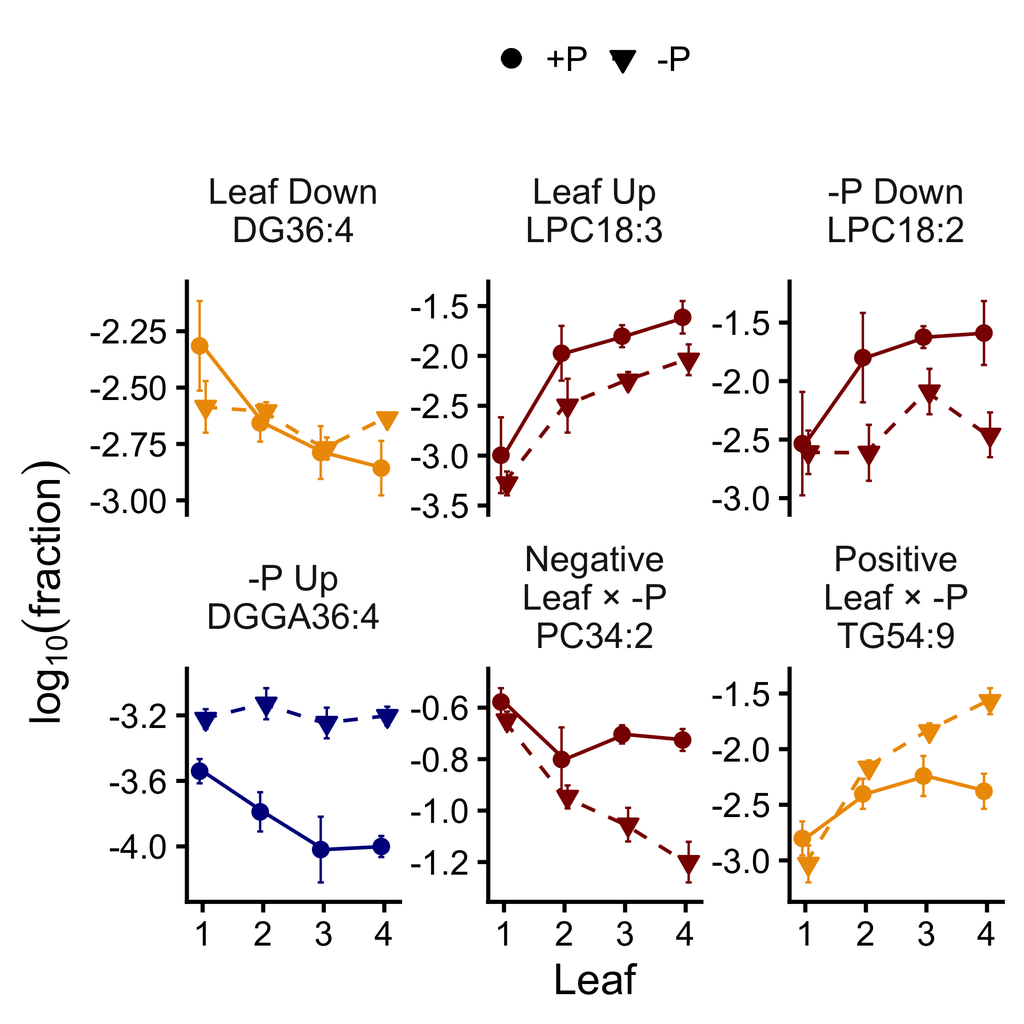